# Lecture 5 Module 6: Histograms and Curves

Exercises

```r
load( "Module 6 R Objects.Rdata" )
```

# Exercises

## Exercise 6.1: Drawing a normal density curve

Construct a graph of the density function for the normal distribution, with mean $\mu = 45$ and standard deviation $\sigma = 7$.

**Solution**

## Exercise 6.2: Superimposing a normal density curve

Draw the histogram of the data in `exercise.6.2.data`. Then superimpose a normal density curve with a mean of 45 and a standard deviation of 7:

**Solution**

## Exercise 6.3: Fitting a normal density curve

Calculate the sample mean and the sample standard deviation of the values in `exercise.6.2.data`. Redraw the histogram, and fit a normal density curve using the sample mean and sample standard deviation.

**Solution**

Construct a histogram of the values in `exercise.6.4.data`, and then superimpose a normal density curve. Finally, superimpose a non-parameteric density curve over this display.

**Solution**

# Solutions to the Exercises

## Exercise 6.1: Drawing a normal density curve

Construct a graph of the density function for the normal distribution, with mean $\mu = 45$ and standard deviation $\sigma = 7$.

**Solution**

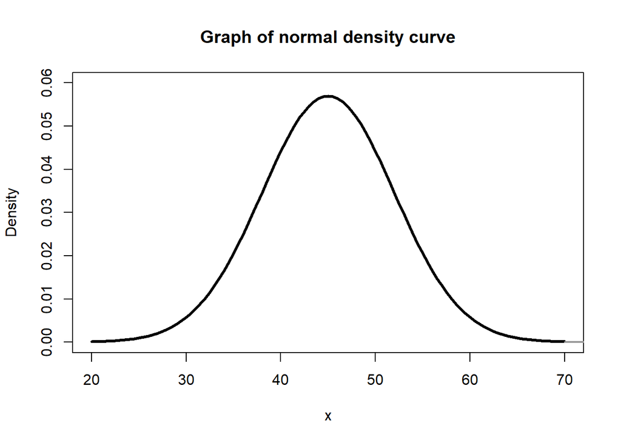

```r
curve(
    dnorm(x, mean = 45, sd = 7),
    main = "Graph of normal density curve",
    xlim = c(20, 70),
    ylim = c(0, 0.06),
    xlab = "x",
    ylab = "Density",
    lty = "solid",
    lwd = 3,
    col = "black"
)


segments(
    x0 = 70,
    y0 = 0,
    x1 = 130,
    y1 = 0,
    lty = "solid",
    lwd = 2,
    col = "gray60"
)
```

## Exercise 6.2: Superimposing a normal density curve

Draw the histogram of the data in `exercise.6.2.data`. Then superimpose a normal density curve with a mean of 45 and a standard deviation of 7:

**Solution**

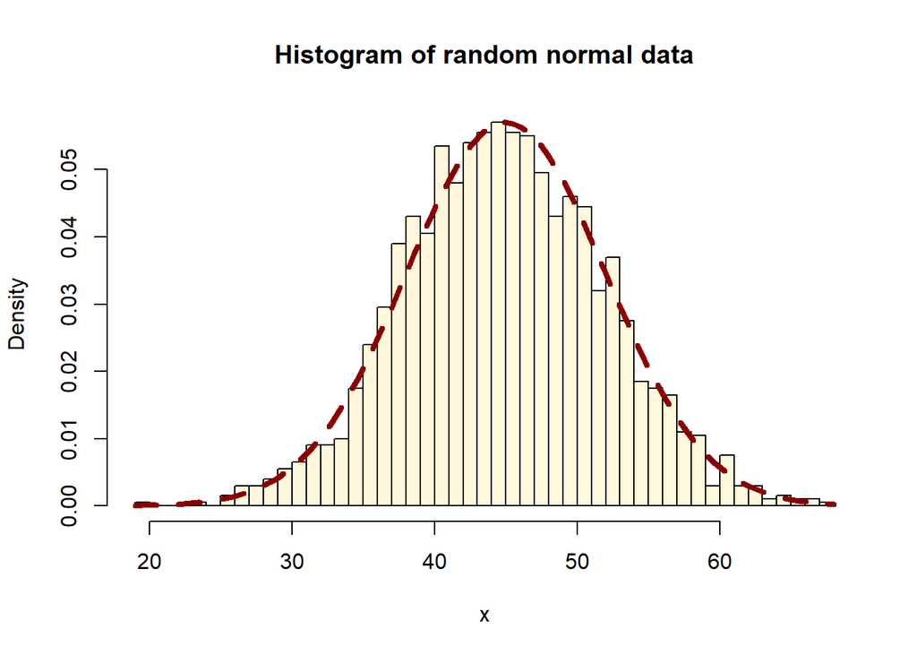

```r
hist(
    exercise.6.2.data,
    prob = TRUE,
    main = "Histogram of random normal data",
    xlab = "x",
    ylab = "Density",
    col = "cornsilk",
    breaks = 50
)

curve(
    dnorm(
        x,
        mean = 45,
        sd = 7
    ),
    lty = "dashed",
    lwd = 4,
    col = "darkred",
    add = TRUE
)
```

## Exercise 6.3: Fitting a normal density curve

Calculate the sample mean and the sample standard deviation of the values in `exercise.6.2.data`. Redraw the histogram, and fit a normal density curve using the sample mean and sample standard deviation.

**Solution**

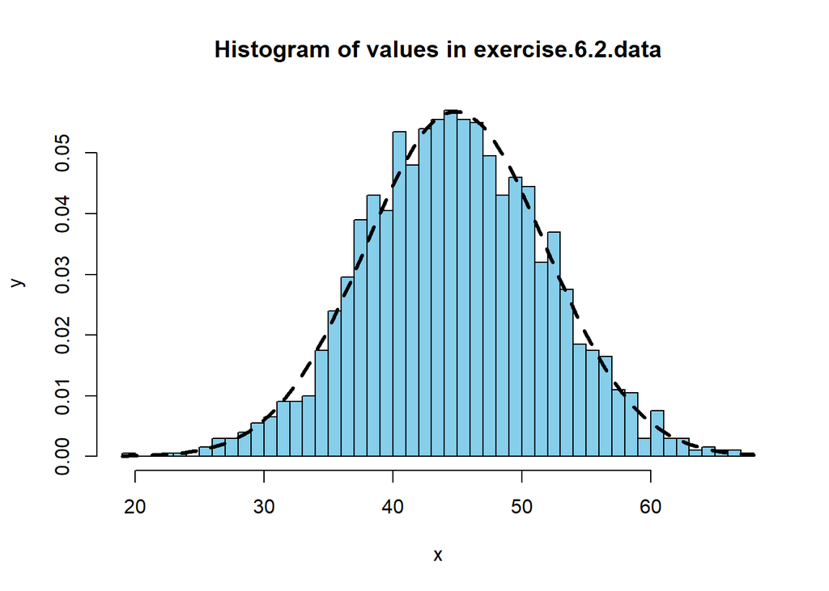

```r
hist(
    exercise.6.2.data,
    main = "Histogram of values in exercise.6.2.data",
    col = "skyblue",
    xlab = "x",
    ylab = "y",
    prob = TRUE,
    breaks = 50
)


sample.mean <-
    mean( exercise.6.2.data )

sample.standard.deviation <-
    sd( exercise.6.2.data )

curve(
    dnorm(
        x,
        mean = sample.mean,
        sd = sample.standard.deviation
    ),
    lty = "dashed",
    lwd = 3,
    col = "black",
    add = TRUE
)
```

## Exercise 6.4: Superimposing a non-parametric density curve

Construct a histogram of the values in `exercise.6.4.data`, and then superimpose a normal density curve. Finally, superimpose a non-parameteric density curve over this display.

**Solution**

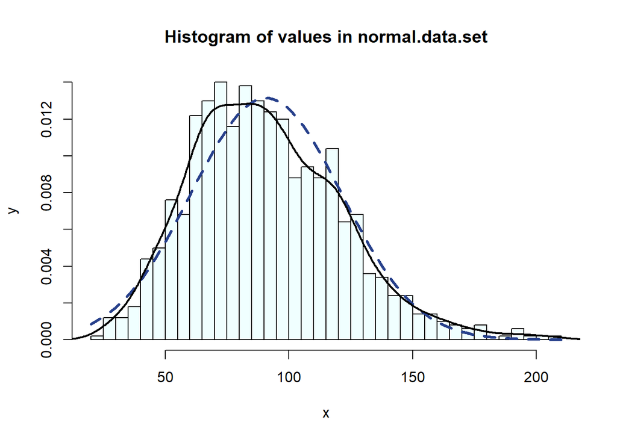

```r
hist(
    exercise.6.4.data,
    main = "Histogram of values in normal.data.set",
    col = "azure1",
    xlab = "x",
    ylab = "y",
    prob = TRUE,
    breaks = 50
)


sample.mean <-
    mean( exercise.6.4.data )

sample.standard.deviation <-
    sd( exercise.6.4.data )

curve(
    dnorm(
        x,
        mean = sample.mean,
        sd = sample.standard.deviation
    ),
    lty = "dashed",
    lwd = 3,
    col = "royalblue4",
    add = TRUE
)

lines(
    density( exercise.6.4.data ),
    lty = "solid",
    lwd = 2,
    col = "black"
)
```